# Intoduction

The classification of ham and spam is one of the problems often faced in the world of information technology, especially in the field of email and messaging. Ham is a message that is considered legitimate and not harmful, while spam is a message that is considered unwanted or not legitimate, such as advertising or phishing messages.

The main rationale in resolving ham and spam cases is to avoid the annoyance or harm that spam messages may cause. For example, if a person receives a lot of spam messages, it can disrupt the performance of the email or messaging that is being used, thus reducing efficiency and productivity. In addition, spam messages can also contain viruses or malware that can damage systems or steal personal data, thus posing a threat to one's security.

By solving ham and spam cases, it is hoped that it can reduce the disruption or losses that may be caused by spam messages, so as to increase efficiency and security in using email or messaging.

## Dataset Understanding

The SMS Spam Collection Data Set is obtained from [UCI Machine Learning Repository](https://archive.ics.uci.edu/ml/datasets/sms+spam+collection). The SMS Spam Collection is a set of SMS tagged messages that have been collected for SMS Spam research. It contains one set of SMS messages in English of 5,574 messages, tagged acording being ham (legitimate) or spam.

## Import Library

```python
import string
import re
import pandas as pd
import numpy as np
import matplotlib.pyplot as plt
import seaborn as sns
from wordcloud import WordCloud
import nltk
from nltk.corpus import stopwords
from nltk.stem import WordNetLemmatizer
from sklearn.preprocessing import LabelBinarizer
from sklearn.feature_extraction.text import CountVectorizer
from sklearn.feature_extraction.text import TfidfVectorizer

import warnings
warnings.filterwarnings("ignore")
pd.options.display.max_columns = 50
sns.set(style='darkgrid')
%matplotlib inline
```

## Load Data

```python
email = pd.read_csv('../Dataset/email-spam.csv')
email.sample(5)
```

|  | label | message |
| --- | --- | --- |
| 1098 | ham | Don't fret. I'll buy the ovulation test strips... |
| 1198 | ham | He also knows about lunch menu only da. . I know |
| 3421 | spam | As a valued customer, I am pleased to advise y... |
| 2777 | ham | Send me your id and password |
| 4533 | ham | Ok both our days. So what are you making for d... |

## Exploratory Data Analysis

```python
email.info()
```

```
<class 'pandas.core.frame.DataFrame'>
RangeIndex: 5572 entries, 0 to 5571
Data columns (total 2 columns):
 #   Column   Non-Null Count  Dtype
---  ------   --------------  -----
 0   label    5572 non-null   object
 1   message  5572 non-null   object
dtypes: object(2)
memory usage: 87.2+ KB
```

The dataframe has two columns named "label", and "message", which are both string data types and have no missing values.

```python
email.groupby('label').describe()
```

| label | message count | message unique | message top | message freq |
| --- | --- | --- | --- | --- |
| ham | 4825 | 4516 | Sorry, I'll call later | 30 |
| spam | 747 | 641 | Please call our customer service representativ... | 4 |

The target variable is either ham or spam. There are 4825 ham messages and 747 spam messages. The following can be presented in percent form!

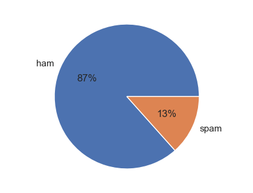

```python
fig = plt.figure(figsize=(4,3))
ax = fig.add_axes([0,0,1,1])
ax.axis('equal')
labels = email['label'].sort_values().unique().tolist()
email_val_count = email.label.value_counts()
ax.pie(email_val_count, labels=labels, autopct='%.0f%%')
plt.show()
```

```python
email['length'] = email['message'].apply(lambda x: len(x.split()) * 1)
email.head()
```

|  | label | message | length |
| --- | --- | --- | --- |
| 0 | ham | Go until jurong point, crazy.. Available only ... | 20 |
| 1 | ham | Ok lar... Joking wif u oni... | 6 |
| 2 | spam | Free entry in 2 a wkly comp to win FA Cup fina... | 28 |
| 3 | ham | U dun say so early hor... U c already then say... | 11 |
| 4 | ham | Nah I don't think he goes to usf, he lives aro... | 13 |

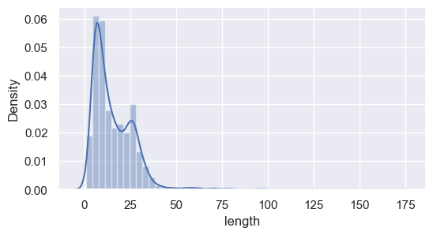

```python
plt.figure(figsize=(6,3))
sns.distplot(email.length)
plt.show()
```

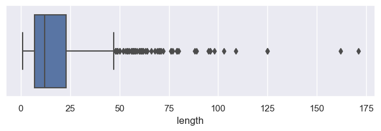

```python
plt.figure(figsize=(8,2))
sns.boxplot(x=email.length)
plt.show()
```

```python
email[email['length'] > 125]['message']
```

```
1085    For me the love should start with attraction.i...
1863    The last thing i ever wanted to do was hurt yo...
Name: message, dtype: object
```

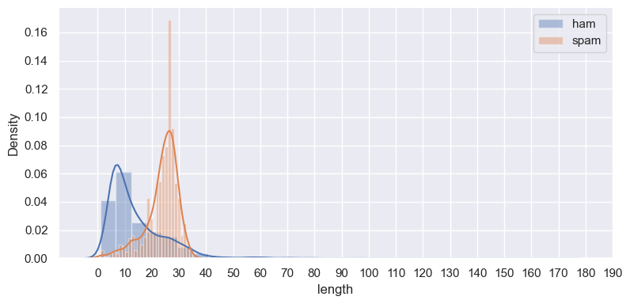

```python
g = sns.FacetGrid(data=email, hue="label", height=4, aspect=2)
g.map(sns.distplot, 'length', bins=30)
g.set(xticks=np.arange(0,200,10))
plt.legend()
plt.show()
```

```python
ham_wordcloud = WordCloud().generate(' '.join(email[email['label'] == 'ham']['message']))
spam_wordcloud = WordCloud().generate(' '.join(email[email['label'] == 'spam']['message']))
```

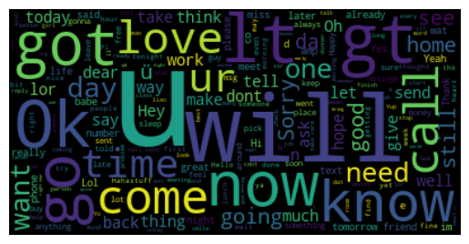

```python
plt.imshow(ham_wordcloud, interpolation='bilinear')
plt.axis("off")
plt.show()
```

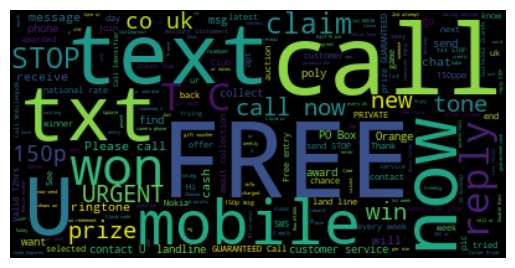

```python
plt.imshow(spam_wordcloud, interpolation='bilinear')
plt.axis("off")
plt.show()
```

# Text Pre-Processing

Text preprocessing is the process of processing text before further analysis or processing. Stages of text preprocessing include Tokenization, Case Folding, Stopword Removal, and Stemming.

These stages can help in preparing the text for further processing, such as clustering, classification, or sentiment analysis. In addition, text preprocessing can also help in reducing noise in the text, making it easier to understand the meaning of the text.

```python
PUNCT_TO_REMOVE = string.punctuation

def text_clean(text):
    text = text.lower()
    # removes all text inside square brackets
    text = re.sub('\[.*?\]', '', text)
    # remove all text that contains the url
    text = re.sub('https?://\S+|www\.\S+', '', text)
    # removes all HTML tags contained in the text
    text = re.sub('<.*?>+', '', text)
    # this pattern will search for all words that contain numbers in them
    text = re.sub('\w*\d\w*', '', text)
    # Remove underline from text
    text = re.sub('\n', ' ', text)
    # remove punctuation
    text = text.translate(str.maketrans('','', PUNCT_TO_REMOVE))
    # Delete more than one space
    text = re.sub(r'\s+', ' ', text)
    return text

email['message_clean'] = email['message'].apply(text_clean)
email[['message_clean']].head()
```

|  | message_clean |
| --- | --- |
| 0 | go until jurong point crazy available only in ... |
| 1 | ok lar joking wif u oni |
| 2 | free entry in a wkly comp to win fa cup final ... |
| 3 | u dun say so early hor u c already then say |
| 4 | nah i dont think he goes to usf he lives aroun... |

```python
nltk.download('stopwords')
```

```
True
```

```python
LIST_STOPWORDS = set(stopwords.words('english'))

# stopword removal
def stopwords_removal(text):
    tokenizer = nltk.RegexpTokenizer(r'\w+')
    tokenizer = tokenizer.tokenize(text)
    stopwords_rmv = [s for s in tokenizer if s not in LIST_STOPWORDS]
    stopwords_rmv = ' '.join(stopwords_rmv)
    return stopwords_rmv

# stemming
def porter_stemmer(text):
    stemmer = nltk.porter.PorterStemmer()
    ps = " ".join([stemmer.stem(word) for word in text.split()])
    return ps
```

```python
email['stopword_rmv'] = email['message_clean'].apply(stopwords_removal)
email['stemmer'] = email['stopword_rmv'].apply(porter_stemmer)
```

```python
email['label'] = LabelBinarizer().fit_transform(email['label'])
email[['stemmer','label']].sample(5)
```

|  | stemmer | label |
| --- | --- | --- |
| 645 | allo brave buse taken train triumph mean b ham... | 0 |
| 1810 | aight ill ask roommat | 0 |
| 389 | half price orang line rental latest camera pho... | 1 |
| 5401 | babe think got ur brolli left english wil brin... | 0 |
| 2692 | hey tmr meet bugi | 0 |

## Splitting Data

```python
from sklearn.model_selection import train_test_split

x_train, x_test, y_train, y_test = train_test_split(email['stemmer'],
                                                    email['label'],
                                                    test_size=0.25,
                                                    random_state=45)
```

## Feature Extraction

The feature extraction process is very important because it can affect the ability of machine learning models to understand and predict data. By selecting the right features, the model can more easily understand the patterns and structure of the data, thus making more accurate predictions.

## Term Frequency–Inverse Document Frequency (TF-IDF)

TF-IDF measures the importance of a word by calculating two factors:

1. Term Frequency (TF): The number of occurrences of a word in a document. The more often the word appears in the document, the higher its importance.
2. Inverse Document Frequency (IDF): The number of documents containing a word compared to the total number of documents. The fewer documents that contain a word, the higher its importance.

```python
tfidf = TfidfVectorizer()
tfidf.fit(x_train.values)
train_tfidf = tfidf.transform(x_train.values)
test_tfidf = tfidf.transform(x_test.values)
```

```python
df_tfidf = pd.DataFrame(train_tfidf.todense().T,
                        index=tfidf.get_feature_names(),
                        columns=[f'D{i+1}' for i in range(len(train_tfidf.toarray()))])
df_tfidf.sample(5)
```

|  | D1 | D2 | D3 | D4 | D5 | D6 | D7 | D8 | D9 | D10 | D11 | D12 | D13 | D14 | D15 | D16 | D17 | D18 | D19 | D20 | D21 | D22 | D23 | D24 | D25 | ... | D4155 | D4156 | D4157 | … |
| --- | --- | --- | --- | --- | --- | --- | --- | --- | --- | --- | --- | --- | --- | --- | --- | --- | --- | --- | --- | --- | --- | --- | --- | --- | --- | --- | --- | --- | --- | --- |
| nowaday | 0.0 | 0.0 | 0.0 | 0.0 | 0.0 | 0.0 | 0.0 | 0.0 | 0.0 | 0.0 | 0.0 | 0.0 | 0.0 | 0.0 | 0.0 | 0.0 | 0.0 | 0.0 | 0.0 | 0.0 | 0.0 | 0.0 | 0.0 | 0.0 | 0.0 | ... | 0.0 | 0.0 | 0.0 | … |
| uncl | 0.0 | 0.0 | 0.0 | 0.0 | 0.0 | 0.0 | 0.0 | 0.0 | 0.0 | 0.0 | 0.0 | 0.0 | 0.0 | 0.0 | 0.0 | 0.0 | 0.0 | 0.0 | 0.0 | 0.0 | 0.0 | 0.0 | 0.0 | 0.0 | 0.0 | ... | 0.0 | 0.0 | 0.0 | … |
| hum | 0.0 | 0.0 | 0.0 | 0.0 | 0.0 | 0.0 | 0.0 | 0.0 | 0.0 | 0.0 | 0.0 | 0.0 | 0.0 | 0.0 | 0.0 | 0.0 | 0.0 | 0.0 | 0.0 | 0.0 | 0.0 | 0.0 | 0.0 | 0.0 | 0.0 | ... | 0.0 | 0.0 | 0.0 | … |
| spirit | 0.0 | 0.0 | 0.0 | 0.0 | 0.0 | 0.0 | 0.0 | 0.0 | 0.0 | 0.0 | 0.0 | 0.0 | 0.0 | 0.0 | 0.0 | 0.0 | 0.0 | 0.0 | 0.0 | 0.0 | 0.0 | 0.0 | 0.0 | 0.0 | 0.0 | ... | 0.0 | 0.0 | 0.0 | … |
| brisk | 0.0 | 0.0 | 0.0 | 0.0 | 0.0 | 0.0 | 0.0 | 0.0 | 0.0 | 0.0 | 0.0 | 0.0 | 0.0 | 0.0 | 0.0 | 0.0 | 0.0 | 0.0 | 0.0 | 0.0 | 0.0 | 0.0 | 0.0 | 0.0 | 0.0 | ... | 0.0 | 0.0 | 0.0 | … |

5 rows × 4179 columns

## Modeling

```python
from sklearn.naive_bayes import MultinomialNB
from sklearn.ensemble import RandomForestClassifier
from sklearn.metrics import classification_report, confusion_matrix
```

### Multinomial Naive Bayes

```python
multinomial_nb = MultinomialNB()
multinomial_nb.fit(train_tfidf, y_train)
```

```
MultinomialNB()
```

```python
multinomial_nb.score(train_tfidf, y_train), multinomial_nb.score(test_tfidf, y_test)
```

```
(0.9770279971284996, 0.9533381191672649)
```

```python
pred = multinomial_nb.predict(test_tfidf)

print('Confusion matrix')
print(confusion_matrix(y_test, pred))
print('\n====================================\n')
print('Classification Report')
print(classification_report(y_test, pred, target_names=['ham','spam']))
```

```
Confusion matrix
[[1211    0]
 [  65  117]]

====================================

Classification Report
              precision    recall  f1-score   support

         ham       0.95      1.00      0.97      1211
        spam       1.00      0.64      0.78       182

    accuracy                           0.95      1393
   macro avg       0.97      0.82      0.88      1393
weighted avg       0.96      0.95      0.95      1393
```

There were 65 messages that the model failed to predict as spam out of a total of 182 spam messages in the dataset. The model is not wrong in classifying normal messages as spam. The resulting accuracy rate is 95%.

### Random Fores Classifier

```python
random_fores = RandomForestClassifier()
random_fores.fit(train_tfidf, y_train)
```

```
RandomForestClassifier()
```

```python
random_fores.score(train_tfidf, y_train), random_fores.score(test_tfidf, y_test)
```

```
(0.9997607083034219, 0.9626704953338119)
```

```python
pred = random_fores.predict(test_tfidf)

print('Confusion matrix')
print(confusion_matrix(y_test, pred))
print('\n====================================\n')
print('Classification Report')
print(classification_report(y_test, pred, target_names=['ham','spam']))
```

```
Confusion matrix
[[1210    1]
 [  51  131]]

====================================

Classification Report
              precision    recall  f1-score   support

         ham       0.96      1.00      0.98      1211
        spam       0.99      0.72      0.83       182

    accuracy                           0.96      1393
   macro avg       0.98      0.86      0.91      1393
weighted avg       0.96      0.96      0.96      1393
```

# Conclusion

Before using machine learning techniques to detect spam messages, I cleaned the dataset of 5572 messages obtained from the UCI Machine Learning Repository by removing punctuation, stop words, and stemming. Then I performed feature extraction using TF-IDF, and trained the data with Naive Bayes and Random Forest algorithms with each being able to detect spam messages well.

However, the model chosen as the best model is Naive Bayes with an overall accuracy of 95%, although the Random Forest model has a higher accuracy of 96% but there is a possibility of overfitting because the accuracy on the training data is higher at 99%.